# Univariate Plots Section

# The plots also shows that the highest number of points are in quality 5 and 6 . The median in 6 is also higher than 5 but in 8 it is the highest . Relation between both Quality and citric can be seen here

```r
cor(red_wine2$quality, red_wine$citric.acid)
```

```
## [1] 0.2263725
```

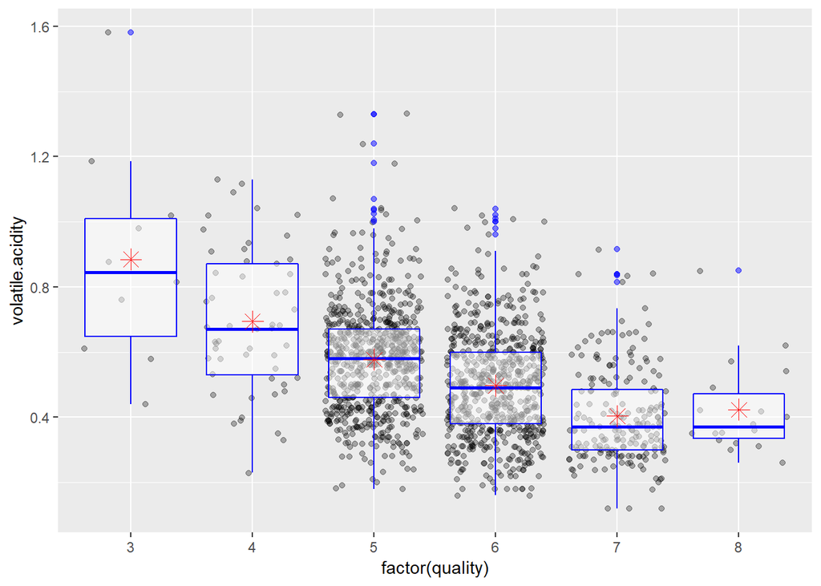

```r
ggplot(aes(factor(quality),
            volatile.acidity),
        data = red_wine2) +
  geom_jitter( alpha = .3)  +
  geom_boxplot( alpha = .5,color = 'blue')+
  stat_summary(fun.y = "mean",
               geom = "point",
               color = "red",
               shape = 8,
               size = 4)
```

# The correlation here as we can see is negative . as more the volatile aciidity the less the quality.

```r
cor(red_wine2$quality, red_wine$volatile.acidity)
```

```
## [1] -0.3905578
```

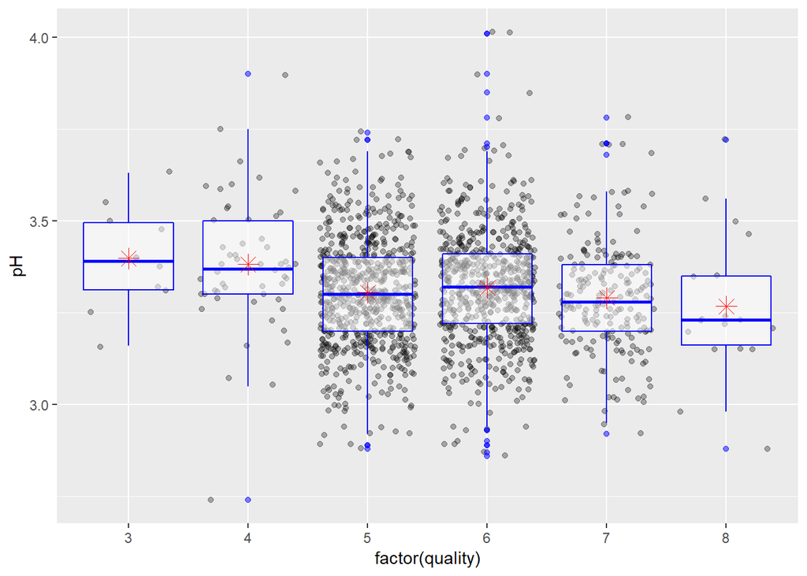

```r
ggplot(aes(factor(quality),
            pH),
        data = red_wine2) +
  geom_jitter( alpha = .3)  +
  geom_boxplot( alpha = .5,color = 'blue')+
  stat_summary(fun.y = "mean",
               geom = "point",
               color = "red",
               shape = 8,
               size = 4)
```

# The correlation here between quality and phis not very clear, when it is calculated we can see that it is negatively correlated but with a very small value = -0.05.

```r
cor(red_wine2$quality, red_wine$pH)
```

```
## [1] -0.05773139
```

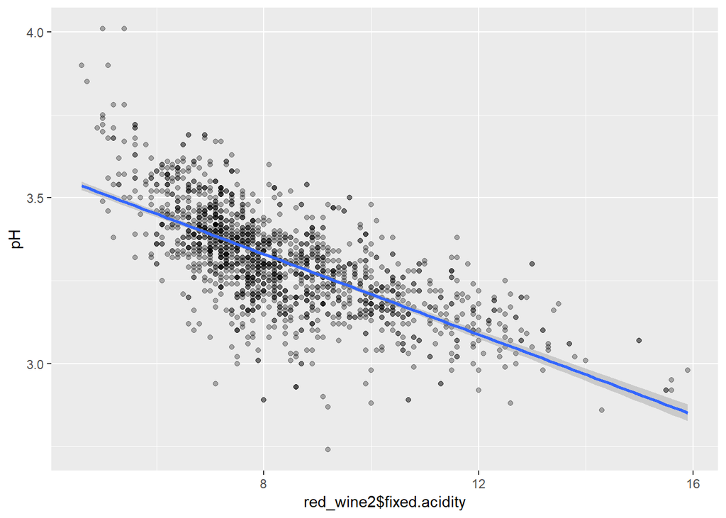

```r
ggplot(aes(x = red_wine2$fixed.acidity, y = pH), data = red_wine2) +
  geom_point(alpha=0.3) +
  stat_smooth(method = 'lm')
```

# This shows the relation between fixed acidity and Ph and as we can see they are negatively related .

```r
cor(red_wine2$fixed.acidity, red_wine$pH)
```

```
## [1] -0.6829782
```

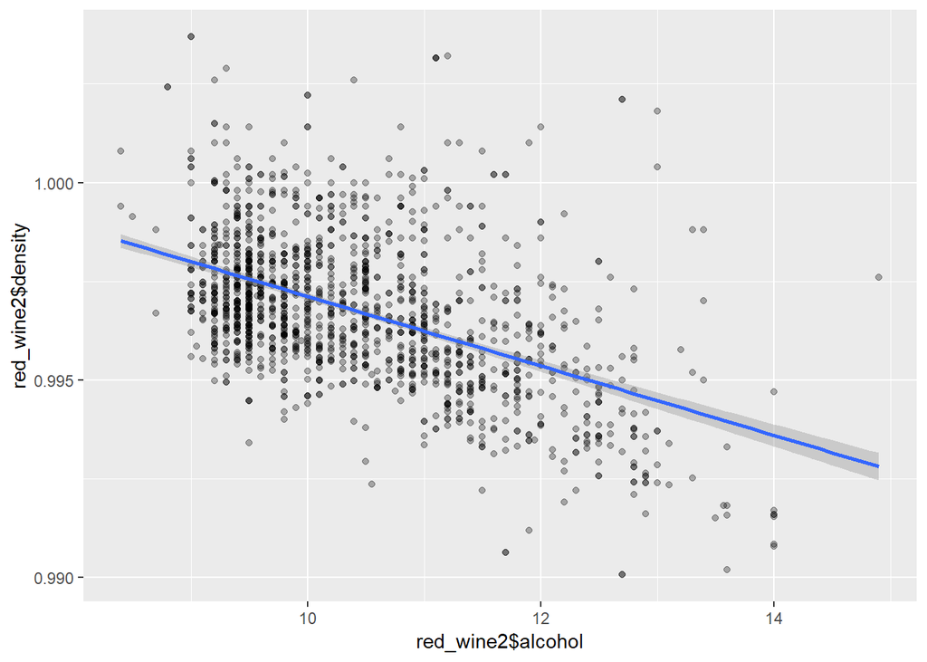

```r
ggplot(aes(x = red_wine2$alcohol, y = red_wine2$density), data = red_wine2) +
  geom_point(alpha=0.3) +
  stat_smooth(method = 'lm')
```

# This show the relation between alcohol and density , it is negative relation with -0.49 .(the negative sign only indicates the direction of the relation )

```r
cor(red_wine2$alcohol, red_wine2$density)
```

```
## [1] -0.4961798
```

```r
#cor( red_wine2$alcohol,red_wine2$density)
#cor(red_wine2$quality,red_wine2$fixed.acidity)
#cor(red_wine2$quality,red_wine2$pH)
#cor(red_wine2$fixed.acidity,red_wine2$pH)
```

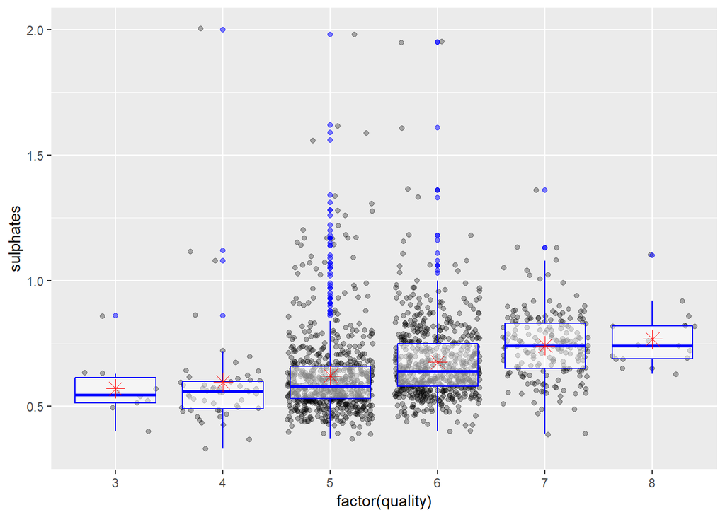

```r
ggplot(aes(factor(quality),
            sulphates),
        data = red_wine2) +
  geom_jitter( alpha = .3)  +
  geom_boxplot( alpha = .5,color = 'blue')+
  stat_summary(fun.y = "mean",
               geom = "point",
               color = "red",
               shape = 8,
               size = 4)
```

Most points are in 5 and 6 . In this graph we can see that the relation between both Quality and sulphates

```r
cor(red_wine2$quality, red_wine2$sulphates)
```

```
## [1] 0.2513971
```

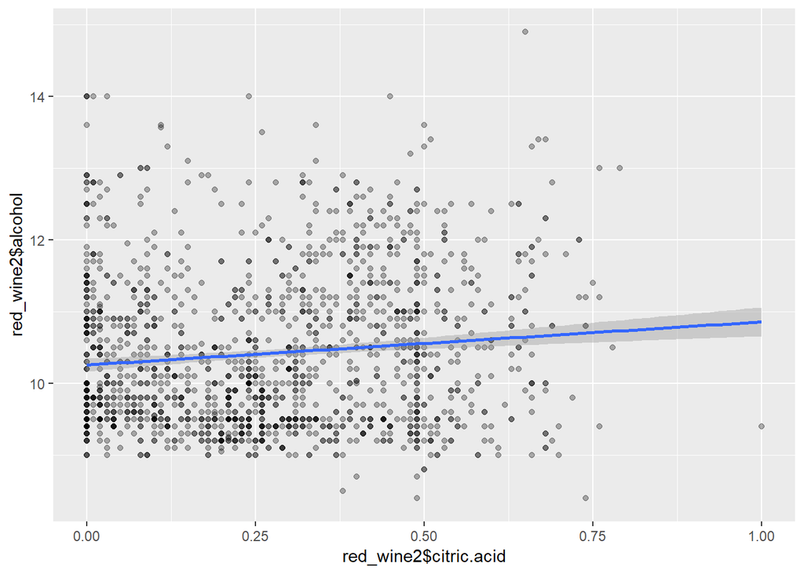

```r
ggplot(aes(x = red_wine2$citric.acid, y = red_wine2$alcohol), data = red_wine2) +
  geom_point(alpha=0.3) +
  stat_smooth(method = 'lm')
```